# Sample-identity check — the target sequencing PN4_SID330 mislabel

Author

Fausto Rodríguez-Zapata

Published

June 26, 2026

**Repo:** sawers-rellan-labs/zealtiger

**Result up front:** the target sequencing sample labelled `PN4_SID330` is **PN4_SID322** — a label/well swap on the target sequencing (MolBreeding) side. The skim `PN4_SID330` is a distinct, correctly-labelled individual.

## Setup

```r
library(tidyverse); library(data.table); library(GenomicRanges)
set.seed(params$seed)

mb   <- read_csv(params$mb_calls,   show_col_types = FALSE)   # target-sequencing wsfilt, r=2 (16 samples)
skim <- read_csv(params$skim_calls, show_col_types = FALSE)   # skim RTIGER r=5 (1393 samples)
cf   <- read_tsv(list.files(params$mb_counts, full.names = TRUE)[1],
                 col_names = c("chr_label","bp","rb","rc","ab","ac"), show_col_types = FALSE)
grid <- tibble(chr = as.integer(sub("chr","",cf$chr_label)), bp = cf$bp) %>% mutate(gi = row_number())
gg   <- GRanges(grid$chr, IRanges(grid$bp, width = 1))

# state-on-grid (0/1/2) for one sample's segment table
state_on_grid <- function(seg) {
  h <- findOverlaps(gg, GRanges(seg$chr, IRanges(seg$start_bp, seg$end_bp)), select = "first")
  seg$state[h]
}
# identity metrics: donor-present Jaccard (robust to skim het-undercall) + state concordance
jac  <- function(a, b) { ok <- !is.na(a) & !is.na(b); a <- a[ok] > 0; b <- b[ok] > 0
  if (sum(a | b) == 0) return(NA_real_); sum(a & b) / sum(a | b) }
conc <- function(a, b) { ok <- !is.na(a) & !is.na(b); if (!any(ok)) return(NA_real_); mean(a[ok] == b[ok]) }

cat(sprintf("query = target sequencing-%s | skim panel = %d samples | grid = %d sites\n",
            params$query, n_distinct(skim$name), nrow(grid)))
```

```
query = target sequencing-PN4_SID330 | skim panel = 1393 samples | grid = 9157 sites
```

## Identity scan — target-sequencing PN4_SID330 vs all 1393 skim samples

```r
q  <- state_on_grid(mb %>% filter(name == params$query))   # target sequencing query
qd <- q > 0

# all skim samples on the grid in one pass (data.table foverlaps)
sk  <- as.data.table(skim)[, .(name, chr = as.character(chr), start_bp, end_bp, state)]
gdt <- as.data.table(grid)[, .(gi, chr = as.character(chr), start = bp, end = bp)]
setkey(sk, chr, start_bp, end_bp)
ov <- foverlaps(gdt, sk, by.x = c("chr","start","end"),
                by.y = c("chr","start_bp","end_bp"), type = "within", nomatch = NULL)

res <- ov[, {
  v <- rep(NA_integer_, nrow(grid)); v[gi] <- state
  .(donorJ = jac(q, v), concord = conc(q, v), skim_donor = mean(v > 0, na.rm = TRUE))
}, by = name][order(-donorJ)]

knitr::kable(head(res, 15), digits = 3,
             caption = "Top 15 skim matches to target-sequencing PN4_SID330 (by donor Jaccard)")
```

Top 15 skim matches to target-sequencing PN4_SID330 (by donor Jaccard)

| name | donorJ | concord | skim_donor |
| --- | --- | --- | --- |
| PN4_SID322 | 0.841 | 0.911 | 0.295 |
| PN8_SID730 | 0.465 | 0.626 | 0.298 |
| PN10_SID874 | 0.435 | 0.686 | 0.290 |
| PN6_SID492 | 0.387 | 0.704 | 0.166 |
| PN10_SID908 | 0.376 | 0.713 | 0.213 |
| PN8_SID720 | 0.360 | 0.649 | 0.300 |
| PN5_SID459 | 0.354 | 0.709 | 0.245 |
| PN6_SID507 | 0.348 | 0.689 | 0.221 |
| PN7_SID642 | 0.347 | 0.620 | 0.249 |
| PN5_SID401 | 0.346 | 0.716 | 0.196 |
| PN13_SID1216 | 0.343 | 0.726 | 0.186 |
| PN3_SID232 | 0.340 | 0.312 | 0.879 |
| PN6_SID512 | 0.330 | 0.696 | 0.139 |
| PN5_SID387 | 0.328 | 0.717 | 0.147 |
| PN3_SID219 | 0.318 | 0.231 | 0.969 |

```r
own <- which(res$name == params$query)
cat(sprintf("\nlabelled skim %s: rank %d / %d  donorJ = %.3f  concord = %.3f\n",
            params$query, own, nrow(res), res$donorJ[own], res$concord[own]))
```

```
labelled skim PN4_SID330: rank 506 / 1393  donorJ = 0.099  concord = 0.633
```

**Read:** a single decisive hit — **PN4_SID322** at donor Jaccard **0.84** / concordance **0.91** — far above the runner-up (~0.47) and the line’s own label (**0.10, rank ~506/1393**). target sequencing-`PN4_SID330` is the same DNA as skim-`PN4_SID322`.

## Ruling out “they’re just sibs”

Both `PN4_SID322` and `PN4_SID330` are family **Zx.0030**, so the match could in principle be close relatives rather than identical DNA. The test: compare the two **skim** samples directly. If they were near-identical sibs, the match would be ambiguous; if they are distinct, target-sequencing 330 ≡ skim-322 can only be a swap.

```r
g330 <- state_on_grid(mb   %>% filter(name == "PN4_SID330"))
k322 <- state_on_grid(skim %>% filter(name == "PN4_SID322"))
k330 <- state_on_grid(skim %>% filter(name == "PN4_SID330"))
tibble(
  comparison = c("skim-322 vs skim-330 (both Zx.0030)",
                 "target-sequencing 330 vs skim-322 (the match)",
                 "target-sequencing 330 vs skim-330 (its own label)"),
  donor_Jaccard = c(jac(k322, k330), jac(g330, k322), jac(g330, k330)),
  concordance   = c(conc(k322, k330), conc(g330, k322), conc(g330, k330)),
  donor_frac_A_vs_B = c(sprintf("%.3f / %.3f", mean(k322>0,na.rm=T), mean(k330>0,na.rm=T)),
                        sprintf("%.3f / %.3f", mean(g330>0,na.rm=T), mean(k322>0,na.rm=T)),
                        sprintf("%.3f / %.3f", mean(g330>0,na.rm=T), mean(k330>0,na.rm=T)))) %>%
  knitr::kable(digits = 3)
```

| comparison | donor_Jaccard | concordance | donor_frac_A_vs_B |
| --- | --- | --- | --- |
| skim-322 vs skim-330 (both Zx.0030) | 0.097 | 0.663 | 0.295 / 0.106 |
| target-sequencing 330 vs skim-322 (the match) | 0.841 | 0.911 | 0.320 / 0.295 |
| target-sequencing 330 vs skim-330 (its own label) | 0.099 | 0.633 | 0.320 / 0.106 |

**Read:** skim-322 vs skim-330 is only **J=0.10** — they are *distinct* individuals (same donor source, independent recombination), no more alike than random NILs. So target-sequencing 330 matching skim-322 at 0.84 while sharing nothing with skim-330 is **not** relatedness — it is a sample swap. Donor fractions agree on the match (target-sequencing 330 0.32 ≈ skim-322 0.30) and disagree on the label (skim-330 0.11).

## Chromosome painting — the swap, in colour

Top = target sequencing `PN4_SID330` (labelled); middle = skim `PN4_SID322` (the J=0.84 match); bottom = skim `PN4_SID330` (its own label, J=0.10). Palette: REF gold, HET green, ALT purple.

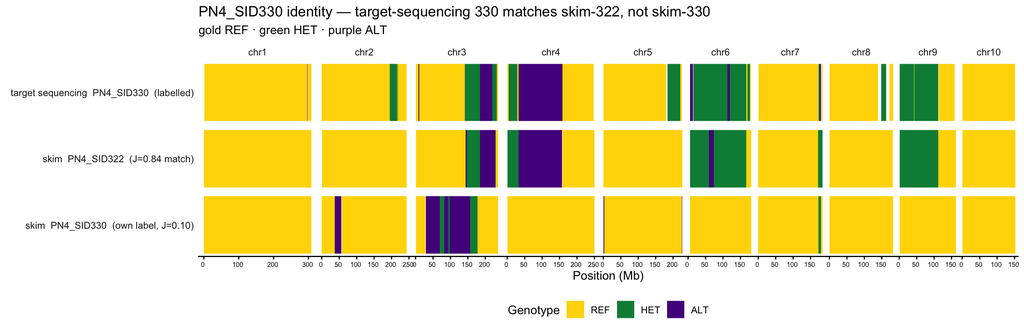

```r
pal <- c(REF = "gold", HET = "springgreen4", ALT = "purple4")
lane <- function(seg, nm, lab) seg %>% filter(name == nm) %>%
  transmute(chr, start_bp, end_bp, state = factor(state, 0:2, c("REF","HET","ALT")), lane = lab)
paint <- bind_rows(
  lane(mb,   "PN4_SID330", "target sequencing  PN4_SID330  (labelled)"),
  lane(skim, "PN4_SID322", "skim  PN4_SID322  (J=0.84 match)"),
  lane(skim, "PN4_SID330", "skim  PN4_SID330  (own label, J=0.10)")) %>%
  mutate(chr  = factor(chr, levels = 1:10, labels = paste0("chr", 1:10)),
         lane = factor(lane, levels = c("target sequencing  PN4_SID330  (labelled)",
                                        "skim  PN4_SID322  (J=0.84 match)",
                                        "skim  PN4_SID330  (own label, J=0.10)")))
ggplot(paint, aes(xmin = start_bp/1e6, xmax = end_bp/1e6, ymin = 0, ymax = 1, fill = state)) +
  geom_rect() +
  facet_grid(lane ~ chr, scales = "free_x", space = "free_x", switch = "y") +
  scale_fill_manual(values = pal, drop = FALSE) +
  scale_x_continuous(labels = scales::unit_format(unit = "", scale = 1)) +
  labs(title = "PN4_SID330 identity — target-sequencing 330 matches skim-322, not skim-330",
       subtitle = "gold REF · green HET · purple ALT", x = "Position (Mb)", fill = "Genotype") +
  ggpubr::theme_classic2(base_size = 11) +
  theme(legend.position = "bottom", strip.background = element_blank(),
        strip.text.y.left = element_text(angle = 0, hjust = 1),
        panel.spacing.x = unit(0.05, "lines"), panel.spacing.y = unit(0.2, "lines"),
        axis.text.y = element_blank(), axis.ticks.y = element_blank(),
        axis.title.y = element_blank(), axis.line.y = element_blank(),
        axis.text.x = element_text(size = 6))
```

**Read:** the target-sequencing 330 and skim-322 lanes share the same introgressions in the same places — the chr4 ALT block, the chr6 and chr9 het blocks, the chr3 het/ALT region. The skim-330 lane (its own label) carries entirely different blocks (chr2, chr3 only) and shares essentially nothing with target-sequencing 330.